# R Notebook

“R” Quiz 1 ### Answer key to be released Tuesday, July 10. ############

READ THIS FIRST!!! Periodically, throughout the summer, I will be circulating short quizzes like the one below. The idea is that if you can complete these quizzes successfully, you have the skills needed for CS112. The first 10 questions will cover basics; the final 5 will be more advanced.

By start of school, you should have a level of R skill that gets you through the first 10 questions. Ideally you would ALSO be able to write the R code for the final 5 questions, but at a minimum you need to be able to read and understand the answer key for these more advanced questions.

I advise you to install R-Studio (in addition to R) on your computer. R-Studio is a popular and practical IDE for R programmers… (https://en.wikipedia.org/wiki/Integrated_development_environment)

I will be holding office hours over the summer – I’ll email you the timing. Ideally, you would save all your code in a “gist” and retain the link to your gist for your records. See: https://help.github.com/articles/creating-gists/

1. Load the “Matching” library.

```r
library(Matching)
```

2. Load the lalonde data set into working memory.

```r
data(lalonde)
```

3. What are the dimensions of the data set?

```r
dim(lalonde)
```

```
[1] 445  12
```

4. What are the names of the columns?

```r
names(lalonde)
```

```
 [1] "age"     "educ"    "black"   "hisp"    "married" "nodegr"  "re74"    "re75"    "re78"    "u74"
[11] "u75"     "treat"
```

5. How many different variable types are represented in this data set?

```r
length(unique(sapply(lalonde, class)))
```

```
[1] 2
```

6. What’s the maximum value of the re74 column? (re74 indicates the person’s real earnings in 1974)

```r
max(lalonde['re74'])
```

```
[1] 39570.7
```

7. What’s the minimum value of this column?

```r
min(lalonde['re74'])
```

```
[1] 0
```

8. How many of the elements of this column are equal to zero?

```r
sum(lalonde['re74'] == 0)
```

```
[1] 326
```

9. How many elements of this column are less than $5000 OR greater than $10000?

```r
sum((lalonde['re74'] < 5000) | (lalonde['re74'] > 10000))
```

```
[1] 409
```

10. How many people in this data set are married and have more than 8 years of education (“educ”)?

```r
sum((lalonde['married'] == 1) & (lalonde['educ'] > 8))
```

```
[1] 68
```

MORE ADVANCED: 11. What is the interquartile range of “re78” (real earnings in 1978)? Use the “quantile” function.

```r
quantile(lalonde$re78, 0.75) - quantile(lalonde$re78, 0.25)
```

```
    75%
8124.72
```

12. Create a scatterplot, with re74 on the x-axis, and re78 on the y-axis. Label the axes. Draw a regression line if you wish (and choose a fun color).

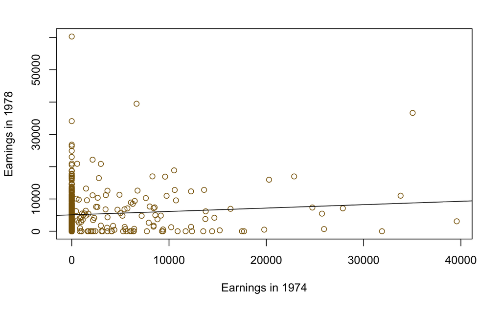

```r
plot(lalonde$re74, lalonde$re78, col = 'darkgoldenrod4', xlab = 'Earnings in 1974', ylab = 'Earnings in 1978')
abline(lm(lalonde$re78 ~ lalonde$re74))
```

13. Make a function with a single argument (column number) that outputs the median of that column. Advanced: if the user specifies a non-numeric column, then the function returns an error message.

```r
function(column){if (is.numeric(column)) {return(median(column))} else return('Error')}
```

```
function(column){if (is.numeric(column)) {return(median(column))} else return('Error')}
```

14. Run a univariate regression, with “age” as a predictor (x variable), re75 as outcome (the “y”). Interpret the 2 coefficients (of the intercept, and the x variable).

```r
lm(formula = lalonde$re75 ~ lalonde$age)
```

```
Call:
lm(formula = lalonde$re75 ~ lalonde$age)

Coefficients:
(Intercept)  lalonde$age
     784.62        23.35
```

‘A person in 1975 should have $784.62 plus $23.35 times their age in real earnings’)

15. Run a regression with 2 predictors, “age” and “educ”, with re75 as the outcome (the “y”). Interpret the 3 coefficients (of the intercept, and the 2 x variables).

```r
lm(lalonde$re75 ~ lalonde$age + lalonde$educ)
```

```
Call:
lm(formula = lalonde$re75 ~ lalonde$age + lalonde$educ)

Coefficients:
 (Intercept)   lalonde$age  lalonde$educ
      348.95         23.10         43.36
```

A person in 1975 should have $348.95 plus $23.10 times their age plus $43.36 for each year of education, in real earnings"